# Probability 2: Loaded dice

In this assignment you will be reinforcening your intuition about the concepts covered in the lectures by taking the example with the dice to the next level.

This assignment will not evaluate your coding skills but rather your intuition and analytical skills. You can answer any of the exercise questions by any means necessary, you can take the analytical route and compute the exact values or you can alternatively create some code that simulates the situations at hand and provide approximate values (grading will have some tolerance to allow approximate solutions). It is up to you which route you want to take!

Note that every exercise has a blank cell that you can use to make your calculations, this cell has just been placed there for you convenience but **will not be graded** so you can leave empty if you want to.

```python
import numpy as np
import pandas as pd
import seaborn as sns
import matplotlib.pyplot as plt
import utils
```

## Some concept clarifications 🎲🎲🎲

During this assignment you will be presented with various scenarios that involve dice. Usually dice can have different numbers of sides and can be either fair or loaded.

- A fair dice has equal probability of landing on every side.
- A loaded dice does not have equal probability of landing on every side. Usually one (or more) sides have a greater probability of showing up than the rest.

Let's get started!

## Exercise 1:

Given a 6-sided fair dice (all of the sides have equal probability of showing up), compute the mean and variance for the probability distribution that models said dice. The next figure shows you a visual represenatation of said distribution:

[figure not shown]

**Submission considerations:**

- Submit your answers as floating point numbers with three digits after the decimal point
- Example: To submit the value of 1/4 enter 0.250

Hints:

- You can use [np.random.choice](https://numpy.org/doc/stable/reference/random/generated/numpy.random.choice.html) to simulate a fair dice.
- You can use [np.mean](https://numpy.org/doc/stable/reference/generated/numpy.mean.html) and [np.var](https://numpy.org/doc/stable/reference/generated/numpy.var.html) to compute the mean and variance of a numpy array.

```python
# You can use this cell for your calculations (not graded)
n_sides = 6

dice = np.array([i for i in range(1, n_sides + 1)])

mean = np.mean(dice)
var = np.var(dice)

print(f"Mean: {mean}")
print(f"Variance: {var}")
```

```
Mean: 3.5
Variance: 2.9166666666666665
```

```python
# Run this cell to submit your answer
utils.exercise_1()
```

```
FloatText(value=0.0, description='Mean:')
```

```
FloatText(value=0.0, description='Variance:')
```

```
Button(button_style='success', description='Save your answer!', style=ButtonStyle())
```

```
Output()
```

## Exercise 2:

Now suppose you are throwing the dice (same dice as in the previous exercise) two times and recording the sum of each throw. Which of the following `probability mass functions` will be the one you should get?

Hints:

- You can use numpy arrays to hold the results of many throws.
- You can sum to numpy arrays by using the `+` operator like this: `sum = first_throw + second_throw`
- To simulate multiple throws of a dice you can use list comprehension or a for loop

```
[Text(0.5, 1.0, 'Histogram of 20000 rolls (sum of rolling twice)')]
```

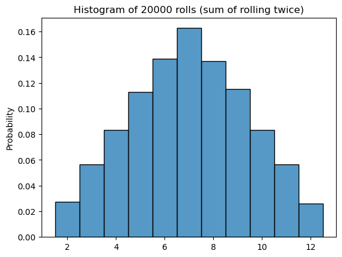

```python
# You can use this cell for your calculations (not graded)
n_rolls = 20000


first_rolls = np.array([np.random.choice(dice) for _ in range(n_rolls)])
second_rolls = np.array([np.random.choice(dice) for _ in range(n_rolls)])

sum_of_rolls = first_rolls + second_rolls

sum_2_rolls_hist = sns.histplot(sum_of_rolls, stat = "probability", discrete = True)
sum_2_rolls_hist.set(title=f"Histogram of {n_rolls} rolls (sum of rolling twice)")
```

```python
# Run this cell to submit your answer
utils.exercise_2()
```

```
ToggleButtons(description='Your answer:', options=('left', 'center', 'right'), value='left')
```

```
Button(button_style='success', description='Save your answer!', style=ButtonStyle())
```

```
Output()
```

## Exercise 3:

Given a fair 4-sided dice, you throw it two times and record the sum. The figure on the left shows the probabilities of the dice landing on each side and the right figure the histogram of the sum. Fill out the probabilities of each sum (notice that the distribution of the sum is symetrical so you only need to input 4 values in total):

[figure not shown]

**Submission considerations:**

- Submit your answers as floating point numbers with three digits after the decimal point
- Example: To submit the value of 1/4 enter 0.250

[output not shown]

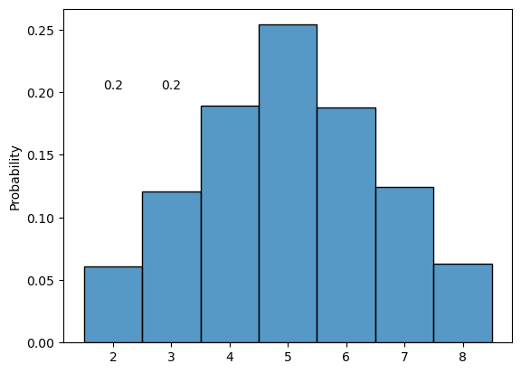

```python
# You can use this cell for your calculations (not graded)
n_sides = 4

dice = np.array([i for i in range(1, n_sides + 1)])

n_rolls = 20000

first_roll = np.array([np.random.choice(dice) for _ in range(n_rolls)])
second_roll = np.array([np.random.choice(dice) for _ in range(n_rolls)])

sum_of_rolls = first_roll + second_roll

sum_of_rolls_hist = sns.histplot(sum_of_rolls, stat = "probability", discrete = True)
# sum_of_rolls_hist.set(title = f"Histogram of {n_rolls} rolls (sum of two rolls)")
# sum_of_rolls_hist.bar_label(loaded_dice_sides.containers[0], fontsize=10)
```

```python
data = pd.DataFrame(sum_of_rolls)
data.value_counts()
```

```
5    5024
6    3831
4    3739
7    2486
3    2448
8    1267
2    1205
dtype: int64
```

```python
print(3739/20000)
```

```
0.18695
```

```python
# Run this cell to submit your answer
utils.exercise_3()
```

```
FloatText(value=0.0, description='P for sum=2|8', style=DescriptionStyle(description_width='initial'))
```

```
FloatText(value=0.0, description='P for sum=3|7:', style=DescriptionStyle(description_width='initial'))
```

```
FloatText(value=0.0, description='P for sum=4|6:', style=DescriptionStyle(description_width='initial'))
```

```
FloatText(value=0.0, description='P for sum=5:', style=DescriptionStyle(description_width='initial'))
```

```
Button(button_style='success', description='Save your answer!', style=ButtonStyle())
```

```
Output()
```

## Exercise 4:

Using the same scenario as in the previous exercise. Compute the mean and variance of the sum of the two throws and the covariance between the first and the second throw:

[figure not shown]

Hints:

- You can use [np.cov](https://numpy.org/doc/stable/reference/generated/numpy.cov.html) to compute the covariance of two numpy arrays (this may not be needed for this particular exercise).

```python
# You can use this cell for your calculations (not graded)
mean = np.mean(sum_of_rolls)
var = np.var(sum_of_rolls)
covar = np.cov(first_roll, second_roll)

print(f"Mean of the sum of the rolls: {mean}")
print(f"Variance of the sum of the rolls: {var}")
print(f"Covariance of the first and second throws: {covar}")
```

```
Mean of the sum of the rolls: 5.0177
Variance of the sum of the rolls: 2.4773867099999998
Covariance of the first and second throws: [[ 1.2488106  -0.01072614]
 [-0.01072614  1.25015226]]
```

```python
# Run this cell to submit your answer
utils.exercise_4()
```

```
FloatText(value=0.0, description='Mean:')
```

```
FloatText(value=0.0, description='Variance:')
```

```
FloatText(value=0.0, description='Covariance:')
```

```
Button(button_style='success', description='Save your answer!', style=ButtonStyle())
```

```
Output()
```